# Part II - (Impact of Loan Features on Borrowers Rate)

## by (Agbons Ekata-Inuaghata)

## Dataset Overview

The dataset consisted of borrower APRs and attributes of 113,937 loans. The attributes utilised included original loan amount, borrower's Prosper rating, loan term, borrower's stated monthly income, as well as many other features such as employment status of borrowers, debt to income ratio, etc. I removed 352 data points from the analysis due to very large stated monthly income which seemed to be outliers also having missing borrower APR information.

## Borrower Rate and Original Loan Amount Distributions

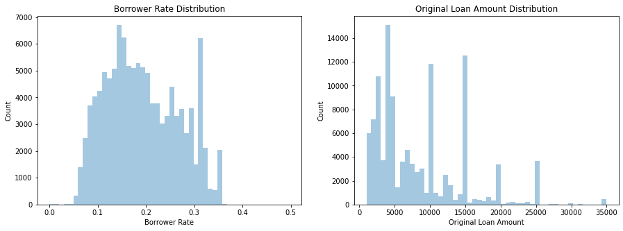

## Year vs Borrower Rate

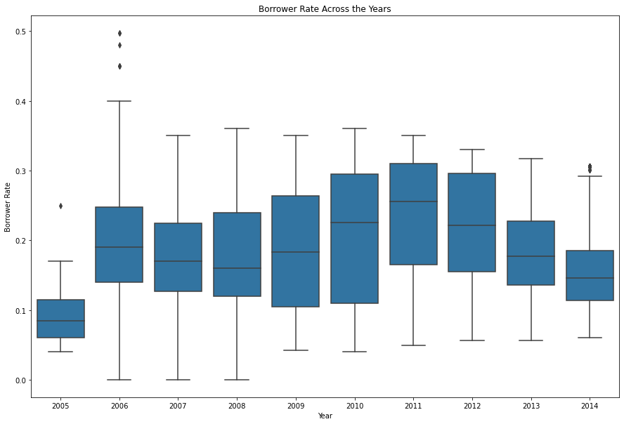

## Borrower rate vs Loan Original Amount and Available Bank Card Credit for all of the data.

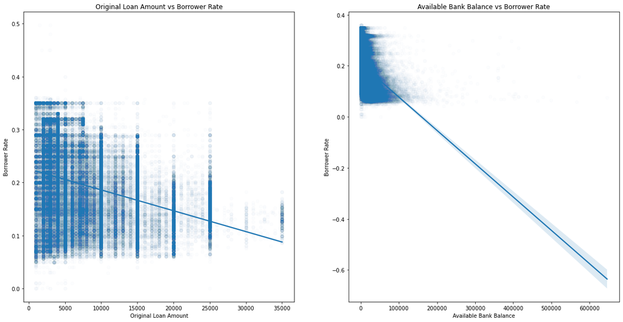

## The Effect of Year on Relationship between Borrower Rate and Loan Amount

Aside from year 2005 which is an outlier because it has just 22 entries, Borrower rate seems to have a negative correlation with original loan amount across all other years. Another observation here is that there is a gradual increase in the loan amounts across the years

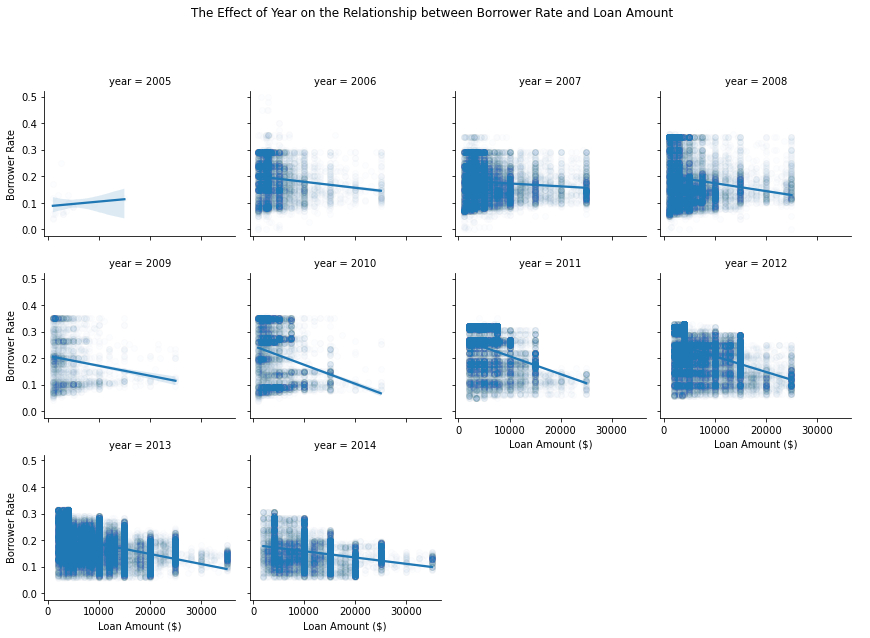

## Loan Status Effect on Relationship between Borrower Rate and Loan Amount

There seems to be a negative relationship across board here. A large category of defaulters seem to have taken smaller loans. I wonder why they are unable to pay their loans, despite their loan amounts being less than the borrowers who completed their loan payments. It could also mesn that the defaulters earn less and may not have very stable employment status

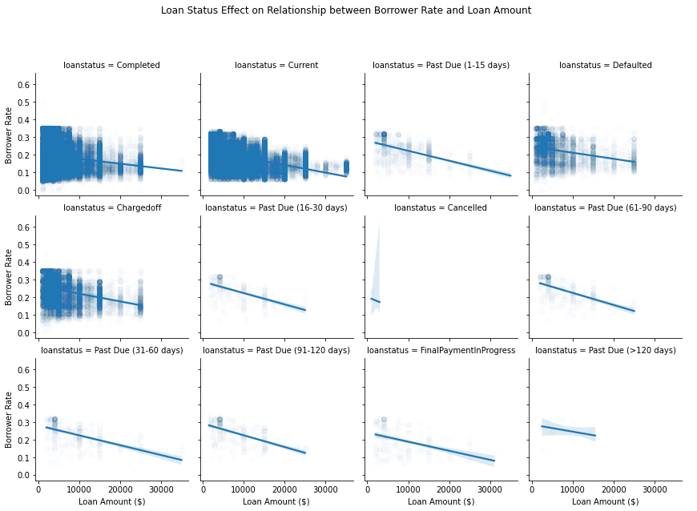